# iris

## Introduction 💡

Hi, nice to see you here! Let's dive into the world of irises!

🌸 **Discover the beauty of Iris species through this dataset that includes details on three distinct types:** 🌸

- Iris setosa
- Iris versicolor
- Iris virginica.

This dataset shows precise measurements of four key features:

- Sepal Length (cm)
- Sepal Width (cm)
- Petal Length (cm)
- Petal Width (cm)

Each row represents an individual flower, with measurement values provided in centimeters. In the following study, we will attempt to identify relationships between the different classes of irises. Are you ready? Let's begin the analysis! 🔎

Just in case, please see table of contents:

1. General Data Overview 📊
2. Analysis of Missing Values 📈
3. Single Variable Analysis 🔍
4. Data Transformation 🔄
5. Analysis of Relationships Between Data 🔍
6. Outlier Analysis 📊
7. Analysis Summary 📋

## 1. General Data Overview 📊

- We simplify the names to make them easier to use.
- Displaying 10 sample rows to provide a general overview of the data.
- All data, except for the class column, are numerical.

|  | długość kielicha | szerokość kielicha | długość płatka | szerokość płatka | klasa |
| --- | --- | --- | --- | --- | --- |
| 33 | 5.5 | 4.2 | 1.4 | 0.2 | Iris-setosa |
| 57 | 4.9 | 2.4 | 3.3 | 1.0 | Iris-versicolor |
| 92 | 5.8 | 2.6 | 4.0 | 1.2 | Iris-versicolor |
| 145 | 6.7 | 3.0 | 5.2 | 2.3 | Iris-virginica |
| 105 | 7.6 | 3.0 | 6.6 | 2.1 | Iris-virginica |
| 114 | 5.8 | 2.8 | 5.1 | 2.4 | Iris-virginica |
| 45 | 4.8 | 3.0 | 1.4 | 0.3 | Iris-setosa |
| 147 | 6.5 | 3.0 | 5.2 | 2.0 | Iris-virginica |
| 103 | 6.3 | 2.9 | 5.6 | 1.8 | Iris-virginica |
| 51 | 6.4 | 3.2 | 4.5 | 1.5 | Iris-versicolor |

- We can observe that there are 150 records in each column, and the data is diverse.

|  | długość kielicha | szerokość kielicha | długość płatka | szerokość płatka |
| --- | --- | --- | --- | --- |
| count | 150.000000 | 150.000000 | 150.000000 | 150.000000 |
| mean | 5.843333 | 3.054000 | 3.758667 | 1.198667 |
| std | 0.828066 | 0.433594 | 1.764420 | 0.763161 |
| min | 4.300000 | 2.000000 | 1.000000 | 0.100000 |
| 25% | 5.100000 | 2.800000 | 1.600000 | 0.300000 |
| 50% | 5.800000 | 3.000000 | 4.350000 | 1.300000 |
| 75% | 6.400000 | 3.300000 | 5.100000 | 1.800000 |
| max | 7.900000 | 4.400000 | 6.900000 | 2.500000 |

- The values in the first four columns are quite diverse.
- In the last column, we have only three distinct classes.
- This column can be used for grouping the data.

```
długość kielicha      35
szerokość kielicha    23
długość płatka        43
szerokość płatka      22
klasa                  3
dtype: int64
```

The dataset is very balanced - each class has exactly 50 records. 📊

```
Iris-setosa        50
Iris-versicolor    50
Iris-virginica     50
Name: klasa, dtype: int64
```

## 2. Analysis of Missing Values 📈

We have no missing values.

```
długość kielicha      0
szerokość kielicha    0
długość płatka        0
szerokość płatka      0
klasa                 0
dtype: int64
```

## 3. Single Variable Analysis 🔍

We can observe that the length and width of the sepal are generally larger than the length and width of the petal.

```
array([[<Axes: title={'center': 'długość kielicha'}>,
        <Axes: title={'center': 'szerokość kielicha'}>],
       [<Axes: title={'center': 'długość płatka'}>,
        <Axes: title={'center': 'szerokość płatka'}>]], dtype=object)
```

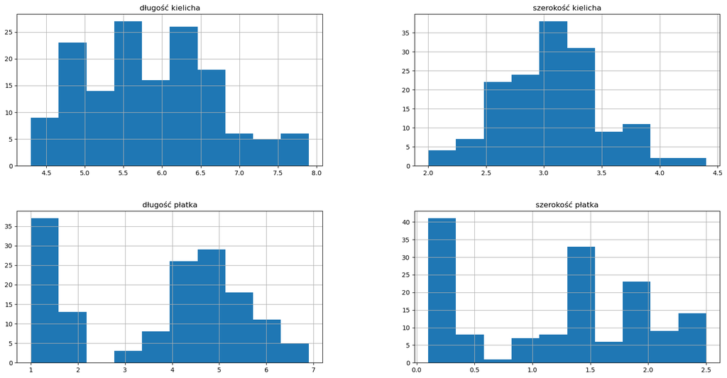

## 4. Data Transformation 🔄

Not necessary, as we have no missing values.

## 5. Analysis of Relationships Between Data 🔍

- The values for Iris-versicolor and Iris-virginica are quite similar when comparing sepal length and sepal width (slightly larger for Iris-virginica).
- Iris-setosa stands out in terms of sepal length and width—it has the largest width and the smallest length.
- When comparing petal length and width, the data for each group is very diverse, with each group having unique values.
- Iris-setosa has the smallest petal length but is characterized by a larger sepal width.
- Iris-versicolor has similar lengths to Iris-virginica.

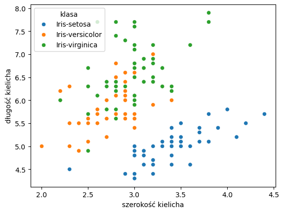

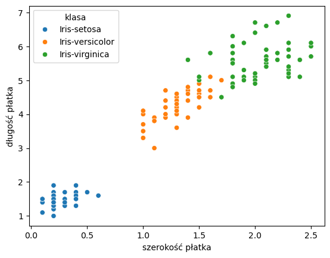

- We can observe a strong correlation between petal length and petal width.
- On the other hand, sepal width and sepal length are the least correlated.

|  | długość kielicha | szerokość kielicha | długość płatka | szerokość płatka |
| --- | --- | --- | --- | --- |
| długość kielicha | 1.000000 | -0.109369 | 0.871754 | 0.817954 |
| szerokość kielicha | -0.109369 | 1.000000 | -0.420516 | -0.356544 |
| długość płatka | 0.871754 | -0.420516 | 1.000000 | 0.962757 |
| szerokość płatka | 0.817954 | -0.356544 | 0.962757 | 1.000000 |

## 6. Outlier Analysis 📊

- We can observe that Iris virginica has the most distant outliers.
- Significant outliers are also present in Iris-setosa.

```
długość kielicha         Axes(0.125,0.11;0.168478x0.77)
długość płatka        Axes(0.327174,0.11;0.168478x0.77)
szerokość kielicha    Axes(0.529348,0.11;0.168478x0.77)
szerokość płatka      Axes(0.731522,0.11;0.168478x0.77)
dtype: object
```

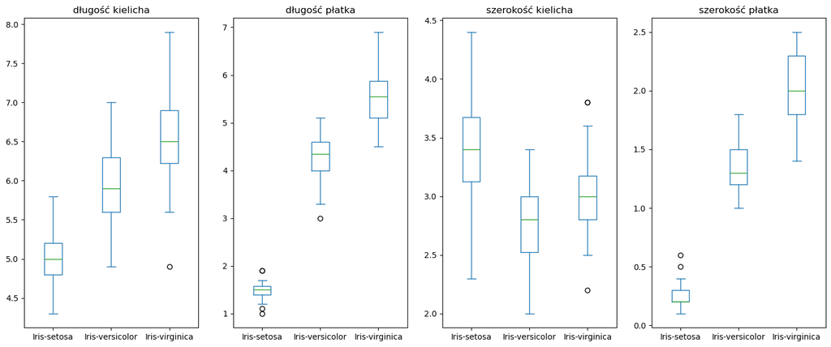

## Analysis Summary

- The data provided for analysis is of very high quality - no missing values and well diversified.
- By excluding data transformation, we preserved their original quality.
- Sepal length and width are generally larger than petal length and width.
- When comparing petal length and width, the data for each group is very diverse, and each group has unique values.

## Thank you for your attention! 🎉 Your interest and time mean a lot.